# Robust Future Study 1: Power Analysis

- Show All Code
- Hide All Code
- View Source

Wave 1 survey · Aotearoa New Zealand and Australia

Author

Delphine PA Dang

Published

November 17, 2026

# 1 Executive summary

**Power check, Study 1.** The proposal says N = 400 gives 80% power for small effects (f² = 0.02). That’s correct (81%), but only for one predictor with complete, error-free data. If RQ1 tests the three stressors together, power is 65% at N = 400; 80% needs 550. With realistic missing data and measurement error, power falls to 59%. The minimum N of 250 gives 61%. Subgroup, moderation and country comparisons are underpowered, so they should be exploratory.

**Recommendations:** name one primary test per thesis, recruit at least 471 completed surveys to keep 400 valid, justify f² from prior studies, keep K10 continuous and set a minimum sample per country.

81% Stated claim: 1 predictor, N = 400

65% RQ1: three stressors together

59% Realistic: missing data + measurement error

471 Completed surveys needed for 400 valid

# 2 Overview

**Question.** Does N = 400 give 80% power to detect small adjusted effects (f² = 0.02) in the Study 1 regression models?

**Method.** Analytic power from the noncentral F distribution (the G*Power method), plus 2,000 simulated datasets per scenario for risks a formula can’t handle. Code: https://github.com/delphinepadang/robust_future

## 2.1 Assumptions

Table 1: Assumptions. All results below are computed from these values.

| Parameter | Value | Source |
| --- | --- | --- |
| Valid sample size (target / minimum) | 400 / 250 | Programme Proposal |
| Effect size | f² = 0.02 (partial r = .14) | Programme Proposal |
| Significance level | α = 0.05 | Programme Proposal |
| Predictors in model (full / subgroup) | 12 / 8 | Assumed |
| Missing data (complete-case) | 15% | Assumed |
| Exclusions at data-quality screening | 15% | Assumed |
| Reliability (climate items / K10) | 0.80 / 0.90 | Assumed |
| Linkage consent (RQ4) | 70% | Assumed |
| RQ3 subgroup size | 100 | Project Plan (80–120) |
| Interaction effect | f² = 0.01 | Assumed |
| Correlation among the three stressors | .30 (.50 in risk scenario) | Assumed |
| Recontact opt-in / wave response | 60% / 70% | Project Plan |

## 2.2 Main results

Table 2: Power for the target effect unless noted. ‘Valid responses needed’ adds back cases lost to missing data or non-consent.

| Scenario | Analysed N | Power | Analysed N for 80% | Valid responses needed |
| --- | --- | --- | --- | --- |
| Stated claim: 1 focal predictor | 400 | 81% | 395 | 395 |
| Stated minimum sample | 250 | 61% | 395 | 395 |
| RQ1: three stressors as one block (3 df) | 400 | 65% | 550 | 550 |
| RQ1: each stressor, Bonferroni (α = .05/3) | 400 | 66% | 527 | 527 |
| Missing data (complete-case) | 340 | 74% | 395 | 465 |
| Measurement error | 400 | 67% | 551 | 551 |
| Missing data + measurement error | 340 | 59% | 551 | 649 |
| RQ4: linkage consent | 280 | 65% | 395 | 565 |
| RQ3 subgroup (subgroup n) | 100 | 29% | 395 | — |
| Interaction effect (f² = 0.01) | 400 | 51% | 787 | 787 |

**Note**

G*Power’s method assumes fixed predictors. Survey predictors are measured, which gives slightly lower power (79% instead of 81% for the stated claim). The conclusions are unchanged.

## 2.3 Additional risks

Table 3: Power at the target sample size under each risk. (sim) = simulation; (approx.) = analytic approximation.

| Risk | Power | What to do |
| --- | --- | --- |
| K10 dichotomised at ‘high distress’ (top 20%) (sim) | 46% | Keep K10 continuous; report cut-offs descriptively |
| Mild climate year: exposure SD 70% of usual (approx.) | 51% | Check exposure spread at the mid-fieldwork review |
| Countries unbalanced 75/25: country interaction (approx.) | 41% | Set per-country minimums (e.g. 150 each) |
| Stressors correlated (r = .5), f² from single-stressor studies | 63% | Base f² on partial effects; report VIFs |
| 10% careless responders not removed (sim) | 72% | Preregister screening rules |
| 20% careless responders not removed (sim) | 63% | Report results with and without exclusions |
| True effect smaller than planned (f² = 0.015) | 69% | Plan on a conservative f² |
| Skewed K10 analysed with OLS (sim) | 81% | Not a power risk; use robust SEs |
| 20 covariate terms instead of 12 | 81% | Minor |

**WarningDon’t look at outcomes during fieldwork**

Checking results halfway (e.g. at the 4 June review) and again at the end raises false positives from 5% to 8.3%. Monitor recruitment counts only.

## 2.4 Power curves

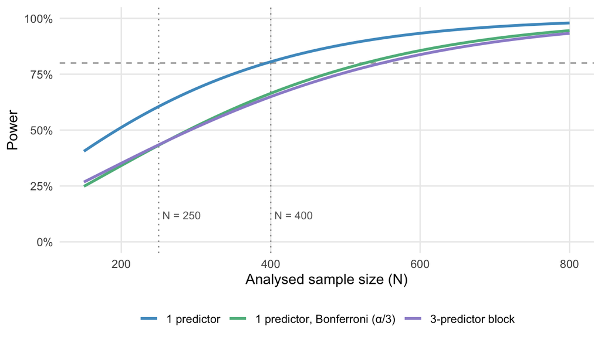

Figure 1: Power to detect the target effect as sample size increases.

# 3 Evidence

## 3.1 Sample size and effect size

Table 4: Power for the target effect by analysed sample size.

| N | Power |
| --- | --- |
| 400 | 81% |
| 340 | 74% |
| 300 | 68% |
| 250 | 61% |

N for 80% power: **395**; for 90% power: **528**.

Table 5: Power if the true effect differs from the target.

| f² | Partial r | Power, N = 400 | Power, N = 340 |
| --- | --- | --- | --- |
| 0.010 | 0.10 | 51% | 45% |
| 0.015 | 0.12 | 69% | 61% |
| 0.020 | 0.14 | 81% | 74% |
| 0.025 | 0.16 | 88% | 83% |
| 0.030 | 0.17 | 93% | 89% |

Table 6: Smallest effect detectable with 80% power (one predictor).

| Model | n | f² | Partial r |
| --- | --- | --- | --- |
| Full (12 predictors) | 400 | 0.020 | 0.14 |
| Full (12 predictors) | 340 | 0.023 | 0.15 |
| Full (12 predictors) | 280 | 0.028 | 0.17 |
| Full (12 predictors) | 250 | 0.032 | 0.18 |
| Full (12 predictors) | 200 | 0.040 | 0.20 |
| Subgroup (8 predictors) | 120 | 0.067 | 0.25 |
| Subgroup (8 predictors) | 100 | 0.080 | 0.27 |
| Subgroup (8 predictors) | 80 | 0.101 | 0.30 |
| Subgroup (8 predictors) | 60 | 0.136 | 0.35 |

## 3.2 Research questions

Table 7: RQ1: three stressors and two outcomes.

| Test | Power at N = 400 | N for 80% |
| --- | --- | --- |
| 3-df block | 65% | 550 |
| Each stressor (α = .05/3) | 66% | 527 |
| 3 stressors × 2 outcomes (α = .05/6) | 57% | 610 |

Table 8: RQ3 subgroup: power by subgroup size and effect size.

| n | f² = 0.02 | f² = 0.05 | f² = 0.10 |
| --- | --- | --- | --- |
| 60 | 19% | 40% | 67% |
| 80 | 24% | 51% | 80% |
| 100 | 29% | 60% | 88% |
| 120 | 34% | 68% | 93% |
| 150 | 41% | 78% | 97% |

Table 9: RQ2 and RQ5: interaction effects at the target sample size.

| Interaction f² | Power at N = 400 | N for 80% |
| --- | --- | --- |
| 0.005 | 29% | 1572 |
| 0.010 | 51% | 787 |
| 0.020 | 81% | 395 |

Table 10: RQ5: unbalanced country split (approx.: interaction f² scales with p(1 − p)).

| Split (larger/smaller) | Smaller country n | Interaction power (assumed f²) | Within-country power (target f²) |
| --- | --- | --- | --- |
| 50/50 | 200 | 51% | 51% |
| 60/40 | 160 | 50% | 43% |
| 75/25 | 100 | 41% | 29% |

Table 11: RQ4: sample after optional linkage consent.

| Linkage consent | n | Power |
| --- | --- | --- |
| 90% | 360 | 76% |
| 70% | 280 | 65% |
| 50% | 200 | 51% |

Table 12: RQ4: area-level exposure. Design effect = 1 + (m − 1) × ICC, where ICC is the outcome’s residual intra-area correlation.

| People per area | ICC | Design effect | Effective N | Power |
| --- | --- | --- | --- | --- |
| 5 | 0.02 | 1.08 | 370 | 77% |
| 10 | 0.02 | 1.18 | 339 | 74% |
| 10 | 0.05 | 1.45 | 276 | 65% |
| 25 | 0.05 | 2.20 | 182 | 47% |

## 3.3 Measurement and design

Table 13: Measurement error (approx.): observed r = true r × √(rel x × rel y).

| Climate items | K10 | Observed f² | Power at N = 400 | N for 80% |
| --- | --- | --- | --- | --- |
| 1.00 | 1.00 | 0.0200 | 81% | 395 |
| 0.80 | 0.90 | 0.0143 | 67% | 551 |
| 0.70 | 0.90 | 0.0125 | 61% | 630 |
| 0.60 | 0.90 | 0.0107 | 54% | 736 |

Table 14: Correlated stressors: unique effect if f² came from single-stressor studies.

| Correlation among stressors | VIF | Partial f² | Power at N = 400 |
| --- | --- | --- | --- |
| 0.0 | 1.00 | 0.0200 | 81% |
| 0.3 | 1.16 | 0.0172 | 75% |
| 0.5 | 1.50 | 0.0133 | 63% |
| 0.7 | 2.36 | 0.0085 | 45% |

Table 15: Exposure range restriction (approx., Thorndike Case II): one fieldwork window may miss drought or flood.

| Exposure SD (vs usual) | Observed f² | Power at N = 400 |
| --- | --- | --- |
| 100% | 0.0200 | 81% |
| 80% | 0.0128 | 62% |
| 70% | 0.0098 | 51% |
| 50% | 0.0050 | 29% |

Table 16: Number of predictors in the model.

| Predictors in model | Power at N = 400 |
| --- | --- |
| 12 | 81% |
| 16 | 81% |
| 20 | 81% |
| 25 | 81% |

## 3.4 Simulation

Table 17: Rejection rates with 95% Monte Carlo intervals (target sample size, assumed stressor correlation, full covariate set).

| Scenario | Rejection rate |
| --- | --- |
| No true effect (Type I error check) | 5% (4%–6%) |
| Planned effect, normal errors | 79% (77%–81%) |
| Skewed outcome, OLS | 81% (79%–82%) |
| Outcome split at the median (logistic) | 59% (56%–61%) |
| Outcome split at top 20% (logistic) | 46% (44%–48%) |
| 10% careless responders | 72% (70%–74%) |
| 20% careless responders | 63% (61%–65%) |

**Checks.** With no true effect the simulation rejects 5% of the time (target 5%). At the planned effect it gives 79%, matching the random-predictor calculation (79%); G*Power’s fixed-predictor method gives 81%.

## 3.5 Recruitment and cohort

Table 18: Completed surveys needed, and the Project Plan’s 280–460 range.

| Exclusion rate | Completions for 400 valid | Valid from 280 | Valid from 460 |
| --- | --- | --- | --- |
| 10% | 445 | 252 | 414 |
| 15% | 471 | 238 | 391 |
| 20% | 500 | 224 | 368 |
| 30% | 572 | 196 | 322 |

Table 19: Cohort size if retention applies only to those who opt in to recontact.

| Recontact opt-in | Wave response | Wave 2 n | Wave 3 n |
| --- | --- | --- | --- |
| 60% | 70% | 168 | 118 |
| 80% | 70% | 224 | 157 |

## 3.6 Code

**Assumptions and power functions**

```r
library(knitr)
library(ggplot2)

# Assumptions: every number in this report is derived from these values ------
alpha_main <- 0.05   # significance level
f2_main    <- 0.02   # target effect size (Cohen's small)
N_target   <- 400    # valid responses (Programme Proposal)
N_min      <- 250    # stated minimum (Programme Proposal)
P          <- 12     # predictors in the adjusted model: 3 focal + ~9 covariate terms
P_sub      <- 8      # predictors in subgroup models (RQ3)
miss       <- 0.15   # cases lost to item non-response (complete-case analysis)
excl       <- 0.15   # completed surveys excluded at data-quality screening
rel_x      <- 0.80   # reliability of study-developed climate items
rel_y      <- 0.90   # reliability of K10
consent    <- 0.70   # optional consent to locality linkage (RQ4)
n_sub      <- 100    # expected RQ3 subgroup size (plan: 80-120)
rho_main   <- 0.30   # correlation among the three stressors
f2_int     <- 0.01   # typical interaction effect
optin      <- 0.60   # recontact opt-in (Project Plan target)
resp       <- 0.70   # response per wave among those recontacted
reps       <- 2000   # simulated datasets per scenario

# Analytic power: noncentral F with lambda = f2 * N (G*Power, fixed predictors) --
power_f2 <- function(f2, n, u = 1, p = P, alpha = alpha_main) {
  v    <- n - p - 1
  crit <- qf(1 - alpha, u, v)
  pf(crit, u, v, ncp = f2 * n, lower.tail = FALSE)
}

n_for_power <- function(f2, target = 0.80, ...) {
  n <- 20
  while (power_f2(f2, n, ...) < target) n <- n + 1
  n
}

f2_detectable <- function(n, target = 0.80, ...) {
  uniroot(function(f2) power_f2(f2, n, ...) - target, c(1e-4, 2))$root
}

f2_to_r  <- function(f2) sqrt(f2 / (1 + f2))                 # partial r, one predictor
r_to_f2  <- function(r) r^2 / (1 - r^2)
r2_j     <- function(rho) { S <- matrix(rho, 3, 3); diag(S) <- 1; 1 - 1 / solve(S)[1, 1] }
restrict <- function(r, k) r * k / sqrt(1 - r^2 + r^2 * k^2)  # Thorndike Case II, k = SD ratio
pct      <- function(x) sprintf("%.0f%%", 100 * x)
# Keep headers and captions in sync with the assumptions
fixn <- function(x) {
  x <- gsub("N = 400", paste("N =", N_target), x, fixed = TRUE)
  x <- gsub("N = 340", paste("N =", N_cc), x, fixed = TRUE)
  gsub("400 valid", paste(N_target, "valid"), x, fixed = TRUE)
}
ktab <- function(df, ...) { names(df) <- fixn(names(df)); kable(df, ...) }

# Derived quantities -----------------------------------------------------------
N_cc    <- round(N_target * (1 - miss))         # analysed after missing data
N_gross <- ceiling(N_target / (1 - excl))       # completed surveys for N_target valid
N_link  <- floor(N_target * consent)            # RQ4 analysed sample
f2_att  <- r_to_f2(f2_to_r(f2_main) * sqrt(rel_x * rel_y))   # attenuated effect
a_lab   <- sub("^0", "", sprintf("%.2f", alpha_main))       # alpha label, e.g. ".05"
```

**Simulation**

```r
# X1 = focal stressor; X2, X3 = correlated stressors; Z = covariates.
# beta is set so the population partial f2 for X1 equals f2.
sim_power <- function(n = N_target, f2 = f2_main, rho = rho_main, k_cov = P - 3,
                      errors = c("normal", "skewed"), cut = NULL, careless = 0) {
  errors <- match.arg(errors)
  S <- matrix(rho, 3, 3); diag(S) <- 1
  L <- chol(S)
  beta <- sqrt(f2 / (1 - r2_j(rho)))
  hits <- logical(reps)
  for (r in seq_len(reps)) {
    X <- matrix(rnorm(n * 3), n) %*% L
    Z <- matrix(rnorm(n * k_cov), n)
    e <- if (errors == "normal") rnorm(n) else {
      v <- rlnorm(n, 0, 0.8)                                  # right-skewed, like K10
      (v - exp(0.32)) / sqrt((exp(0.64) - 1) * exp(0.64))    # mean 0, variance 1
    }
    y <- beta * X[, 1] + 0.1 * X[, 2] + 0.1 * X[, 3] + Z %*% rep(0.1, k_cov) + e
    if (careless > 0) {
      # Random responders answer each item independently, so their stressor
      # scores are uncorrelated with each other and with their outcome.
      idx <- sample(n, round(careless * n))
      X[idx, ] <- matrix(rnorm(length(idx) * 3), length(idx))
      y[idx] <- sample(y, length(idx))
    }
    d <- data.frame(y = as.numeric(y), X, Z)
    p <- if (is.null(cut)) {
      summary(lm(y ~ ., d))$coefficients["X1", 4]
    } else {                                                  # outcome dichotomised
      d$y <- as.integer(d$y > quantile(d$y, 1 - cut))
      summary(glm(y ~ ., binomial, d))$coefficients["X1", 4]
    }
    hits[r] <- p < alpha_main
  }
  mean(hits)
}

set.seed(2027)
sim <- c(
  null     = sim_power(f2 = 0),
  baseline = sim_power(),
  skewed   = sim_power(errors = "skewed"),
  median   = sim_power(cut = 0.5),
  top20    = sim_power(cut = 0.2),
  care10   = sim_power(careless = 0.1),
  care20   = sim_power(careless = 0.2)
)

# Two looks at the data (halfway and at the end), each at alpha = .05
z1 <- rnorm(1e6); z2 <- sqrt(0.5) * z1 + sqrt(0.5) * rnorm(1e6)
two_looks <- mean(abs(z1) > qnorm(1 - alpha_main / 2) | abs(z2) > qnorm(1 - alpha_main / 2))
```